# Adlucent Associate Data Scientist Assignment: Question 3

Ian Douglas

11/14/2022

```r
library(lubridate)
library(knitr)
library(viridis)
library(lme4)
library(lmerTest)
library(kableExtra)
library(MLmetrics)
library(caret)
library(tseries)
library(forecast)
library(GGally)
library(cluster)
library(parallel)
#library(tidymodels)
suppressPackageStartupMessages(library(tidyverse))
# Custom function to convert monetary notation to floating point / double
dollar_to_numeric = function(.) {
  # Assumes format: $ dollars (any number of digits) . cents (2-digits)
  dollars = as.numeric(gsub('$|[[:punct:]]', '', substr(., 1, nchar(.) - 2)))
  cents = substr(., nchar(.) - 1, nchar(.))
  as.numeric(paste(dollars, cents, sep = '.'))
}
```

# Setup & EDA

```r
set.seed(1)
```

### Read in the data

```r
df <- read_tsv("../data/Question3.tsv")
print(sapply(df, class))
head(df)
```

[output not shown]

### Make more convenient names

```r
df = df %>% rename_with(~gsub(' ', '.', .)) %>%
  rename(N.articles = Number.of.Articles.in.Order)
```

### Convert `Order Revenue` to numeric

```r
df = df %>% mutate(across(Order.Revenue, dollar_to_numeric))
```

### Get a sense of data size/shape

```r
print(setNames(dim(df), c('rows', 'columns')))
```

```
##    rows columns
##   12323       5
```

```r
print(paste0('Are there NaN? ', anyNA(df)))
```

```
## [1] "Are there NaN? FALSE"
```

```r
psych::describe(df %>% select(where(is.numeric))) %>% kbl('html') %>% kable_styling()
```

|  | vars | n | mean | sd | median | trimmed | mad | min | max | range | skew | kurtosis | se |
| --- | --- | --- | --- | --- | --- | --- | --- | --- | --- | --- | --- | --- | --- |
| Customer.ID | 1 | 12323 | 15227.4097 | 1747.661 | 15078.0 | 15210.5686 | 2326.1994 | 12347.00 | 18283.00 | 5936.00 | 0.0758212 | -1.235251 | 15.743415 |
| Order.ID | 2 | 12323 | 558655.6037 | 12842.563 | 558419.0 | 558587.7139 | 16068.4188 | 536367.00 | 581586.00 | 45219.00 | 0.0463450 | -1.138768 | 115.689375 |
| N.articles | 3 | 12323 | 297.8672 | 623.318 | 167.0 | 195.5452 | 152.7078 | 1.00 | 15049.00 | 15048.00 | 10.3024877 | 158.897200 | 5.615022 |
| Order.Revenue | 4 | 12323 | 515.6503 | 1080.100 | 310.8 | 346.6314 | 234.4880 | 0.38 | 31698.16 | 31697.78 | 11.1844052 | 184.648797 | 9.729840 |

### How big is the sample of orders and customers

```r
map(df %>% select(Customer.ID, Order.ID), n_distinct)
```

```
## $Customer.ID
## [1] 1277
##
## $Order.ID
## [1] 12323
```

There are 1277 customers, and a total of 12323 orders (the number of rows). This implies there aren’t any duplicates as well.

### Distribution of `Revenue`

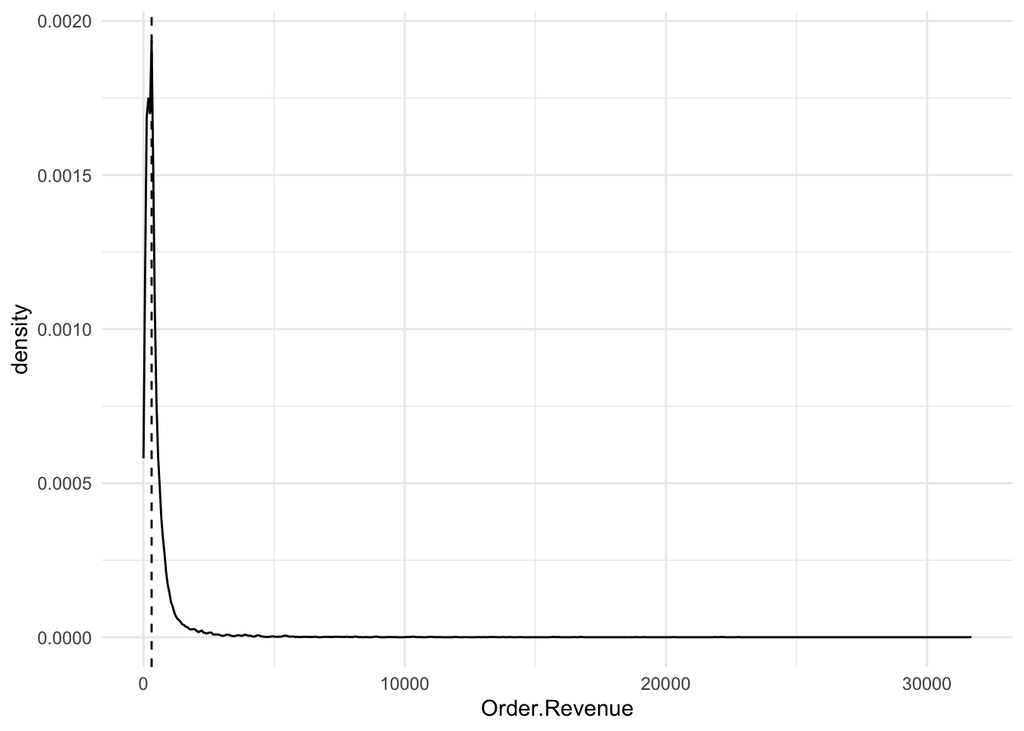

```r
ggplot(df) +
  geom_density(aes(x = Order.Revenue)) +
  geom_vline(aes(xintercept = median(Order.Revenue)), linetype=2) +
  theme_minimal()
```

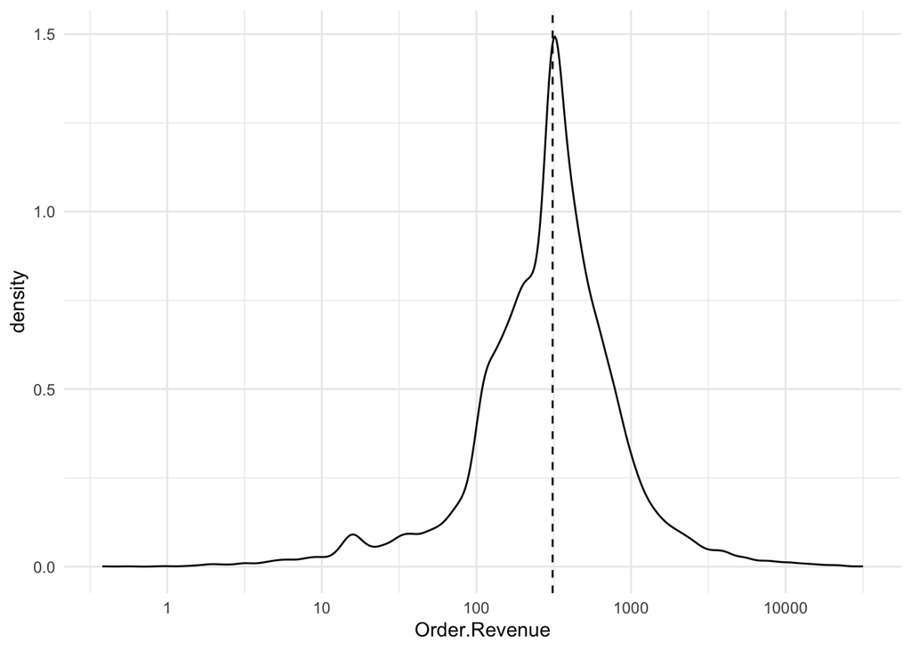

```r
ggplot(df) +
  geom_density(aes(x = Order.Revenue)) +
  scale_x_log10() +
  geom_vline(aes(xintercept = median(Order.Revenue)), linetype=2) +
  theme_minimal()
```

The data is roughly normal after log-transforming Revenue, but there is an overabundance of customers with Revenue values near the median. Heretofore use log revenue instead of revenue

### Customer behaviors

In order to classify a new customer as a valuable customer, it may be worthwhile to try to define valuable, based on the behaviors of existing customers. As a result, I will engineer variables to summarize their behavior across their interactions with the company, for example computing things like the median Revenue per article, the total number of articles, and the frequency with which they place orders.

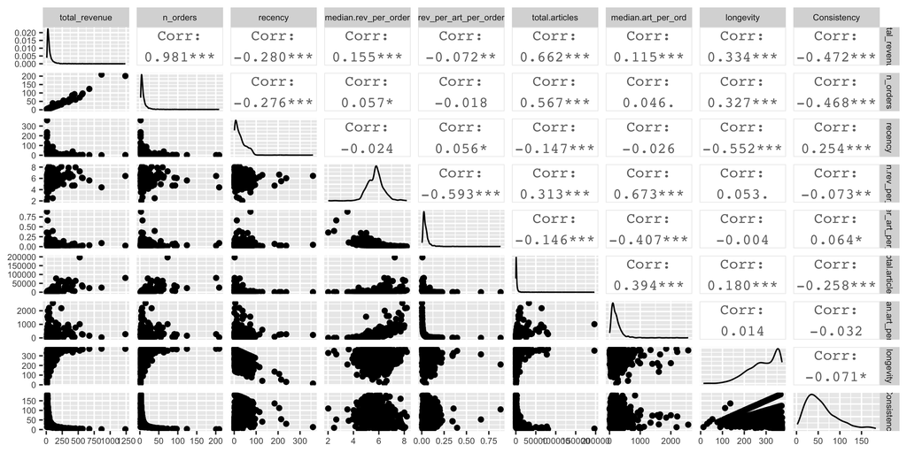

```r
beh = df %>%
  mutate(Order.Revenue = log(Order.Revenue)) %>%
  group_by(Customer.ID) %>%
  summarise(
    total_revenue = sum(Order.Revenue), # sum of all revenue from customer
    n_orders = n(), # number of orders in total
    # how recent was the last order?
    recency = as.numeric((max(df$Order.Date) + 1) - max(Order.Date)),
    # median order revenue, per order
    median.rev_per_order = median(Order.Revenue),
    # price of article, per order
    rev_per_art_per_order = median(Order.Revenue / N.articles),
    # sum total number of articles ordered
    total.articles = sum(N.articles),
    # the  number of articles per order (median):
    median.art_per_ord = median(N.articles),
    # this variable captures how long customers's orders span in time
    longevity = as.numeric(max(Order.Date) - min(Order.Date)),
    # this counts how much time lags between orders
    Consistency = as.numeric(mean(diff(Order.Date)))
  )

### Plot relationships between variables
p = ggpairs(beh %>% select(-Customer.ID))
ggsave(plot=p + theme(text = element_text(size = 8)),
      filename = "pairs.png", units = 'px', width = 2*1400, height = 2*700)
```

Viewing the correlations and distributions of this multivariate data can help us understand how to model it, and which features might be useful for predicting revenue.

Conclusions:

1. The number of orders is positively skewed
2. # of orders and recency show a heavy positive skew
3. Consistency is one of the strongest correlates of revenue
4. Skewed variables should be transformed prior to modeling
5. Median revenue per order is one of the most normally distributed varaibles, and might make a good target for modeling
6. Longevity is right-censored
7. Several variables might be redundant with one another

# Modeling

## Option 1

1. Cluster customers based on the above behavioral variables
2. Place our new customers into a cluster based on existing data
3. Using cluster means for variables like number of orders, median revenue per order, and total revenue, predict how many orders the customer will make in all, and the total revenue

### Find clusters

To run kmeans, the data should be normalized. Since several variable are skewed, and kmeans uses means to quantify distance between customers and cluster centroids, the data are best transformed prior to clustering.

Since there are some examples of multicolinearity in the data, and since several variables have been engineered out of just a couple columns, PCA is a wise choice to do both dimension reduction and normalization.

```r
# get the data formatted, log transform skewed variables
cluster_dat = beh %>% select(-Customer.ID, -longevity) %>%
  mutate(across(c(total_revenue, n_orders, recency, rev_per_art_per_order,
                  total.articles, median.art_per_ord),
                log)) %>%
  as.matrix

# Fit pca model
pca = prcomp(cluster_dat, center = T, scale. = T, retx=T)

# Fit the cluster model
cluster_model = kmeans(x = pca$x[,1:3], centers = 4)
# get the distance matrix to assess of cluster fit
D = dist(pca$x[,1:3], 'euc') # distance matrix
mean(silhouette(cluster_model$cluster, D)[, 'sil_width'])
```

```
## [1] 0.2758473
```

4 clusters seems like a reasonable solution

### Read in the test data and process it as the train data was

```r
test = read.table(
  textConnection("
17811 540566 2011-01-10 83 $185.97
17811 541648 2011-01-20 166 $337.70
17811 542149 2011-01-26 120 $108.55
17811 542929 2011-02-02 105 $289.30
17811 543801 2011-02-13 52 $210.70
17811 543839 2011-02-14 30 $103.70
17811 544450 2011-02-20 497 $1,271.55
17811 544642 2011-02-22 50 $139.80
17811 545279 2011-03-01 53 $122.50
17811 545700 2011-03-06 150 $166.45
17811 546524 2011-03-14 45 $110.84
17811 547197 2011-03-21 30 $108.42
17811 549048 2011-04-06 42 $113.10
17811 549830 2011-04-12 57 $117.83
17811 551870 2011-05-04 132 $194.30
17811 553423 2011-05-17 90 $187.42
17811 554362 2011-05-24 43 $150.35
17811 555548 2011-06-05 99 $147.05
17811 558107 2011-06-26 75 $124.76
17811 559671 2011-07-11 55 $114.95
17811 560820 2011-07-21 127 $146.66
17811 563062 2011-08-11 70 $120.42
17811 563843 2011-08-19 57 $108.94
17811 566042 2011-09-08 90 $182.90"), sep = ' '
) %>%
  set_names(names(df)) %>%
  mutate(across(Order.Revenue, dollar_to_numeric),
         across(Order.Date, as.Date))
test.beh = test %>%
  mutate(Order.Revenue = log(Order.Revenue)) %>%
  group_by(Customer.ID) %>%
  summarise(
    total_revenue = sum(Order.Revenue),
    n_orders = n(),
    recency = as.numeric((max(df$Order.Date) + 1) - max(Order.Date)),
    median.rev_per_order = median(Order.Revenue),
    rev_per_art_per_order = median(Order.Revenue / N.articles),
    total.articles = sum(N.articles),
    median.art_per_ord = median(N.articles),
    longevity = as.numeric(max(Order.Date) - min(Order.Date)),
    Consistency = as.numeric(mean(diff(Order.Date)))
  )
test.cluster_dat = test.beh %>%
  select(-Customer.ID, -longevity) %>%
  mutate(across(c(total_revenue, n_orders, recency, rev_per_art_per_order,
                  total.articles, median.art_per_ord),
                log)) %>%
  as.matrix

pca.test = predict(pca, newdata = test.cluster_dat)[, 1:3]
```

### Classify test customer

Compute the Mean Squared residual between the new customer’s data and the centroid of each cluster.

We use this to assign the customer where MSE is minimized

```r
centroids = cluster_model$centers
for (i in 1:nrow(centroids)) {
  print(MSE(centroids[i, ], pca.test))
}
```

```
## [1] 2.413387
## [1] 7.585298
## [1] 7.3317
## [1] 4.872944
```

This customer would be classified into cluster 1.

```r
# Get the revenue predictions from the untransformed data
df %>%
  filter(Customer.ID %in% beh$Customer.ID[cluster_model$cluster ==1]) %>%
  group_by(Customer.ID) %>%
  summarise(total_revenue = sum(Order.Revenue)) %>%
  summarise(difference = median(total_revenue) - sum(test$Order.Revenue))
```

```
## # A tibble: 1 × 1
##   difference
##        <dbl>
## 1     -2532.
```

Unfortunately, the predicted Revenue for the customer is already less than what they have generated so far in the test data. The model is likely ill-fitting.

# Conclusions

### Regression model

A sensible second approach would be to take some of the features extracted from the past order history, and fit regression models

1. A first model could be fit to predict the number of orders based on other aspects of customer behavior
2. A second could predict the revenue per order, based on the same predictors
3. Finally, predicting both number of orders and revenue per order, we could multiply the predictions of each (minus the number of orders already placed) to estimate total revenue for this customer